# Proyecto Módulo 3

Pronóstico de ventas semanales con contexto

Equipo 8

# Datos

## La serie y la ventana a pronosticar

```r
load("datos/ventas_semana_train.RData")

revision <- ventas_semana_train |>
  as_tibble() |>
  summarise(semanas = n(), inicio = format(min(semana)), fin = format(max(semana)),
            faltantes = sum(is.na(total)), no_positivas = sum(total <= 0))
huecos <- has_gaps(ventas_semana_train)$.gaps
```

- **290 semanas**, de 2021 W01 a 2026 W30.
- Huecos: **no**; faltantes: **0**; ventas ≤ 0: **0**.
- Se pronostican **12 semanas**: 2026-W31 a W42 (sombreado).
- Mismos datos y horizonte que el M2; ahora el modelo debe **saber qué pasa alrededor de la serie**.

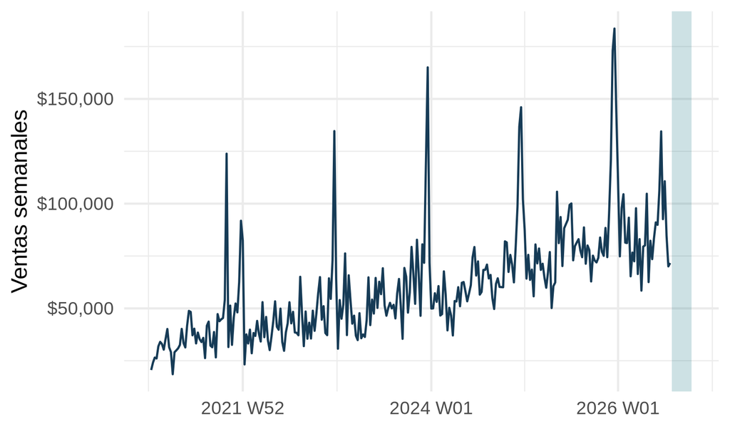

## Escala: logaritmo para toda la familia de regresión

- La desviación estándar crece con el nivel, aunque **menos que proporcionalmente** (el coeficiente de variación baja).
- Guerrero da λ = **0.33** con los datos hasta el primer origen de la validación y λ = **0.46** con todos: λ **no es estable**.
- Candidatas: **original**, **Box-Cox** (λ = 0.33, sin datos futuros) y **log**. Se decide con validación cruzada, **la misma escala para ARIMA y TSLM**.

| Año ISO | Media (pesos) | Desv. est. (pesos) | Coef. de variación |
| --- | --- | --- | --- |
| 2021 | 40,381 | 17,738 | 0.44 |
| 2022 | 45,163 | 16,401 | 0.36 |
| 2023 | 57,440 | 21,864 | 0.38 |
| 2024 | 65,250 | 19,931 | 0.31 |
| 2025 | 82,853 | 25,028 | 0.30 |
| 2026 (W01–W30) | 86,048 | 16,991 | 0.20 |

# Regresores

## Festivos oficiales: Ley Federal del Trabajo, art. 74

```r
lunes_n <- function(anio, mes, n) {           # n-ésimo lunes del mes
  primero <- as.Date(sprintf("%d-%02d-01", anio, mes))
  primero + ((1 - wday(primero, week_start = 1)) %% 7) + 7 * (n - 1)
}

festivos_mx <- function(anios) {
  lapply(anios, function(a) tibble(
    fecha = c(as.Date(sprintf("%d-01-01", a)), lunes_n(a, 2, 1), lunes_n(a, 3, 3),
              as.Date(sprintf("%d-05-01", a)), as.Date(sprintf("%d-09-16", a)),
              lunes_n(a, 11, 3), as.Date(sprintf("%d-12-25", a))),
    motivo = c("Año Nuevo", "Día de la Constitución", "Natalicio de Benito Juárez",
               "Día del Trabajo", "Independencia", "Revolución Mexicana", "Navidad")
  )) |>
    bind_rows() |>
    bind_rows(tibble(fecha = as.Date("2024-10-01"),          # cambio de Poder Ejecutivo
                     motivo = "Transmisión del Poder Ejecutivo Federal"))
}

festivos <- festivos_mx(2020:2026)
viernes_santo <- as.Date(Easter(2021:2026)) - 2              # timeDate::Easter()
```

| Fecha 2026 | Día | Semana ISO | Motivo |
| --- | --- | --- | --- |
| 2026-01-01 | jueves | 2026 W01 | Año Nuevo |
| 2026-02-02 | lunes | 2026 W06 | Día de la Constitución |
| 2026-03-16 | lunes | 2026 W12 | Natalicio de Benito Juárez |
| 2026-05-01 | viernes | 2026 W18 | Día del Trabajo |
| 2026-09-16 | miércoles | 2026 W38 | Independencia |
| 2026-11-16 | lunes | 2026 W47 | Revolución Mexicana |
| 2026-12-25 | viernes | 2026 W52 | Navidad |

## De días a semanas: los regresores

```r
calendario <- tibble(fecha = seq(as.Date("2020-12-28"), as.Date("2026-10-18"), by = "day")) |>
  mutate(semana = yearweek(fecha), dia_semana = wday(fecha, week_start = 1)) |>
  group_by(semana) |>
  summarise(
    festivos = sum(dia_semana <= 6 & fecha %in% festivos$fecha),   # festivos lunes-sábado
    semana_santa = as.integer(any(fecha %in% viernes_santo)),
    .groups = "drop"
  ) |>
  mutate(evento_2021w43 = as.integer(semana == yearweek("2021 W43"))) |>
  as_tsibble(index = semana)

datos <- ventas_semana_train |>
  left_join(calendario, by = "semana")
```

| Regresor | Definición | ¿Conocido de antemano? |
| --- | --- | --- |
| `festivos` | Festivos oficiales de lunes a sábado en la semana (días hábiles perdidos) | Sí: calendario |
| `semana_santa` | 1 en la semana que contiene el Viernes Santo | Sí: se calcula la Pascua |
| `evento_2021w43` | 1 solo en 2021-W43 (venta atípica) | Sí: vale 0 a futuro |
| `fourier(period = "year", K)` | Pares seno-coseno con periodo de 52.18 semanas | Sí: depende solo de la fecha |
| `trend()` (solo TSLM) | Tendencia lineal | Sí |

## Evidencia: festivos y Semana Santa venden menos

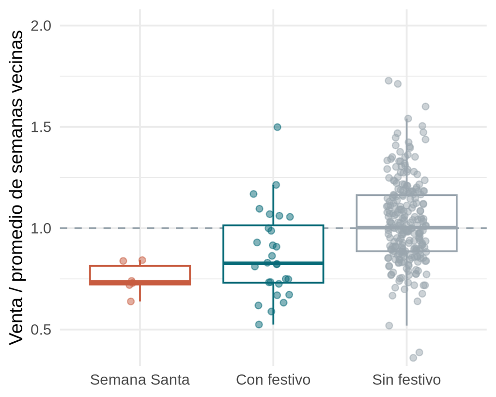

| Semana | n | Mediana de la razón | % por debajo de sus vecinas |
| --- | --- | --- | --- |
| Semana Santa | 6 | 0.73 | 100% |
| Con festivo | 28 | 0.83 | 75% |
| Sin festivo | 243 | 1.00 | 49% |

## Semana Santa, año por año

| Semana con Viernes Santo | Venta (pesos) | Promedio vecinas (pesos) | Razón |
| --- | --- | --- | --- |
| 2021 W13 | 18,567 | 29,084 | 0.64 |
| 2022 W15 | 30,088 | 35,719 | 0.84 |
| 2023 W14 | 35,736 | 42,627 | 0.84 |
| 2024 W13 | 37,066 | 50,101 | 0.74 |
| 2025 W16 | 50,156 | 68,756 | 0.73 |
| 2026 W14 | 58,482 | 81,266 | 0.72 |

## La semana del 16 de septiembre (W38 del concurso)

| Semana | Día del 16 | Venta (pesos) | Promedio vecinas (pesos) | Razón |
| --- | --- | --- | --- | --- |
| 2021 W37 | jueves | 26,597 | 42,982 | 0.62 |
| 2022 W37 | viernes | 43,158 | 35,559 | 1.21 |
| 2023 W37 | sábado | 35,458 | 60,228 | 0.59 |
| 2024 W38 | lunes | 64,357 | 60,947 | 1.06 |
| 2025 W38 | martes | 62,856 | 76,500 | 0.82 |

- En 3 de 5 años vendió **menos** que sus vecinas: razón media **0.86**, casi igual que los otros festivos (**0.88**).
- Solo subió cuando el 16 cayó en **viernes o lunes** (puente). En 2026 cae en **miércoles**.
- La “noche mexicana” no compensa el día cerrado: la W38 se queda como un festivo más.

## Un evento atípico: 2021-W43

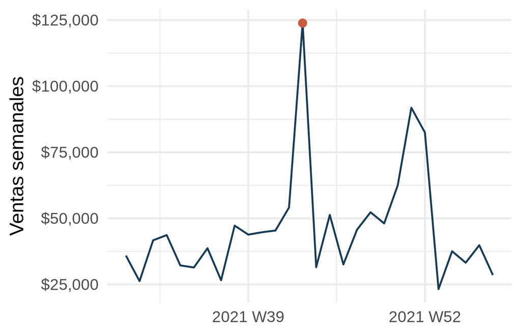

**Semanas más altas respecto a sus vecinas (sin diciembre):**

| Semana | Venta (pesos) | Razón |
| --- | --- | --- |
| 2021 W43 | 123,862 | 2.89 |
| 2023 W05 | 76,238 | 1.71 |
| 2021 W45 | 51,318 | 1.60 |
| 2022 W32 | 65,073 | 1.54 |
| 2022 W11 | 52,960 | 1.50 |

## Estacionalidad: Fourier con periodo de 52.18 semanas

- Un año tiene 365.25/7 = **52.18 semanas**. Los años ISO tienen 52 o 53 semanas: **2020 y 2026 tienen 53**.
- SNAIVE redondea el periodo a 52 (el warning “Non-integer lag orders… Rounding” del benchmark) y su patrón se recorre ~1.25 días por año.
- `fourier(period = "year", K)` usa el **periodo exacto, no entero**: el patrón anual no se desfasa.
- El número de pares **K** se elige con validación cruzada (siguiente sección), no a ojo.

## Valores de los regresores en las 12 semanas a pronosticar

```r
futuro <- new_data(ventas_semana_train, 12) |>
  left_join(calendario, by = "semana")
```

| Semana | Del | Al | festivos | semana_santa | evento_2021w43 |
| --- | --- | --- | --- | --- | --- |
| 2026 W31 | 27 jul | 02 ago | 0 | 0 | 0 |
| 2026 W32 | 03 ago | 09 ago | 0 | 0 | 0 |
| 2026 W33 | 10 ago | 16 ago | 0 | 0 | 0 |
| 2026 W34 | 17 ago | 23 ago | 0 | 0 | 0 |
| 2026 W35 | 24 ago | 30 ago | 0 | 0 | 0 |
| 2026 W36 | 31 ago | 06 sep | 0 | 0 | 0 |
| 2026 W37 | 07 sep | 13 sep | 0 | 0 | 0 |
| 2026 W38 | 14 sep | 20 sep | 1 | 0 | 0 |
| 2026 W39 | 21 sep | 27 sep | 0 | 0 | 0 |
| 2026 W40 | 28 sep | 04 oct | 0 | 0 | 0 |
| 2026 W41 | 05 oct | 11 oct | 0 | 0 | 0 |
| 2026 W42 | 12 oct | 18 oct | 0 | 0 | 0 |

# Modelado

## ¿Por qué este modelo?

| Lo que muestra la serie | Decisión de modelado |
| --- | --- |
| El año dura **52.18 semanas**; los años ISO tienen 52 o 53 (2020 y 2026 tienen 53) | Estacionalidad con **Fourier** (`period = "year"` admite periodo no entero) y errores con `PDQ(0, 0, 0)`; K se elige con VC |
| La dispersión crece con el nivel y el λ de Guerrero no es estable (0.33 vs 0.46) | **log(total)**, la misma escala para ARIMA y TSLM, elegida con VC frente a Box-Cox y original |
| Con festivo, la semana vende **0.83** de lo de sus vecinas; en Semana Santa, **0.73**, y esa semana se mueve de W13 a W16 | Indicadoras **festivos** y **semana_santa**: la caída va a la semana correcta, cosa que un patrón estacional fijo no logra |
| 2021-W43 vendió **2.89** veces lo de sus vecinas (la siguiente semana más alta: 1.71) | Indicadora **evento_2021w43**, que vale 0 a futuro |
| El nivel crece: media anual de **40,381** (2021) a **82,853** (2025) | Dos formas de seguirlo: **diferencia** en los errores del ARIMA y **tendencia lineal** en la TSLM |
| Una supone que el nivel se queda y la otra que el crecimiento sigue; la TSLM tiende a pasarse | **Combinación (ARIMA + TSLM) / 2**: reparte ese desfase |

Todos los regresores se conocen el 26 de julio de 2026 (pronóstico ex ante). Cada decisión se comprueba con validación cruzada en las diapositivas siguientes.

## Candidatos

| Familia | Modelo | Escala | Regresores |
| --- | --- | --- | --- |
| Benchmark | STL + ARIMA no estacional + SNAIVE | Original | Ninguno |
| Sin regresores (tipo M2) | STL + Holt amortiguado + SNAIVE; STL + ARIMA no estacional + SNAIVE | Holt: original y log; ARIMA: log | Ninguno |
| Regresión dinámica | ARIMA(log(total) ~ Fourier + calendario) | Log (K = 4, 6, 8, 10); Box-Cox y original (K = 8) | Fourier + calendario |
| Regresión lineal | TSLM(log(total) ~ trend + Fourier + calendario) | Log (K = 4, 6, 8, 10); Box-Cox y original (K = 8) | Fourier + calendario |
| Combinación | (ARIMA + TSLM) / 2 | Log | Fourier K = 8 + calendario |

```r
spec_benchmark <- decomposition_model(
  STL(total ~ season(period = "year"), robust = TRUE),
  ARIMA(season_adjust ~ PDQ(0, 0, 0))
)
```

## Validación cruzada: diseño

```r
entrenamiento_cv <- datos |>
  filter(semana <= yearweek("2026 W18")) |>
  stretch_tsibble(.init = 158, .step = 4)            # ventana creciente

fin_folds <- entrenamiento_cv |>
  as_tibble() |>
  group_by(.id) |>
  summarise(fin = max(semana))

prueba_cv <- fin_folds |>                             # 12 semanas de prueba por fold
  reframe(semana = fin + 1:12, h = 1:12, .by = .id) |>
  left_join(as_tibble(datos), by = "semana") |>
  as_tsibble(index = semana, key = .id)
```

- **31 folds**, h = 12, `.step = 4`.
- Primer entrenamiento: 158 semanas (2024 W02).
- Último entrenamiento: 2026 W18 → su prueba termina en 2026-W30.
- Regresores construidos **antes** de partir.

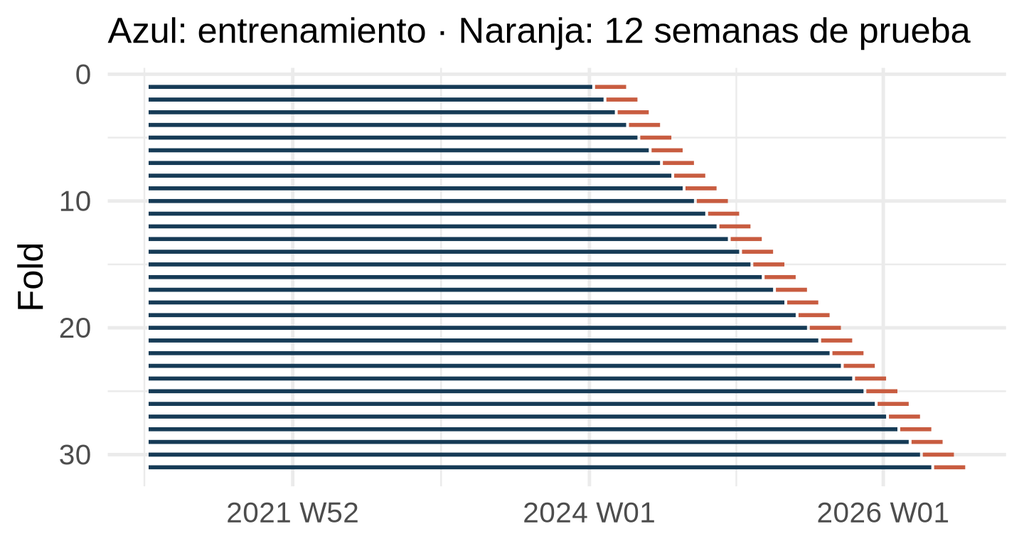

## Funciones de evaluación

```r
errores_cv <- function(fc) {
  fc |>
    as_tibble() |>
    select(.model, .id, semana, .mean) |>
    left_join(as_tibble(prueba_cv) |> select(.id, semana, h, total), by = c(".id", "semana")) |>
    mutate(ape = 100 * abs(total - .mean) / total,           # error porcentual absoluto
           pe = 100 * (.mean - total) / total)                # error con signo (sesgo)
}

resumen_cv <- function(err) {
  err |>
    group_by(.model, .id) |>
    summarise(mape = mean(ape), sesgo = mean(pe), .groups = "drop") |>   # MAPE_k
    group_by(.model) |>
    summarise(MAPE_CV = mean(mape), mediana = median(mape), peor_fold = max(mape),
              sesgo = mean(sesgo), .groups = "drop") |>                   # (1/K) Σ MAPE_k
    arrange(MAPE_CV)
}
```

$$\text{MAPE}_{\text{CV}} = \frac{1}{K}\sum_{k=1}^{K}\text{MAPE}_k, \qquad \text{sesgo} = \frac{1}{K}\sum_{k=1}^{K}\frac{100}{12}\sum_{h=1}^{12}\frac{\hat y_{k,h}-y_{k,h}}{y_{k,h}}$$

## Elección de K y de la escala

```r
calendario_txt <- "festivos + semana_santa + evento_2021w43"
escalas <- c(log = "log(total)",
             boxcox = sprintf("box_cox(total, %.4f)", lambda_inicio),   # λ sin datos futuros
             original = "total")

# 1. Orden de los errores ARIMA elegido automáticamente con todos los datos
orden_auto <- function(respuesta, k) {
  f <- as.formula(sprintf("%s ~ fourier(period = 'year', K = %d) + %s + PDQ(0, 0, 0)",
                          respuesta, k, calendario_txt))
  spec <- (datos |> model(m = ARIMA(!!f)))$m[[1]]$fit$spec
  tibble(p = spec$p, d = spec$d, q = spec$q, constante = spec$constant)
}

# 2. Especificaciones con ese orden fijo (incluida la constante) para la validación cruzada
arima_fijo <- function(respuesta, k, o) {
  ARIMA(!!as.formula(sprintf(
    "%s ~ %d + fourier(period = 'year', K = %d) + %s + pdq(%d, %d, %d) + PDQ(0, 0, 0)",
    respuesta, as.integer(o$constante), k, calendario_txt, o$p, o$d, o$q)))
}
tslm_spec <- function(respuesta, k) {
  TSLM(!!as.formula(sprintf("%s ~ trend() + fourier(period = 'year', K = %d) + %s",
                            respuesta, k, calendario_txt)))
}

candidatos_k <- bind_rows(
  tibble(escala = "log", K = c(4, 6, 8, 10)),
  tibble(escala = c("boxcox", "original"), K = 8)
) |>
  mutate(orden = Map(orden_auto, escalas[escala], K))

modelos_k <- list()
for (i in seq_len(nrow(candidatos_k))) {
  e <- candidatos_k$escala[i]; k <- candidatos_k$K[i]
  modelos_k[[sprintf("ARIMA_K%d_%s", k, e)]] <- arima_fijo(escalas[e], k, candidatos_k$orden[[i]])
  modelos_k[[sprintf("TSLM_K%d_%s", k, e)]] <- tslm_spec(escalas[e], k)
}

fit_cv_k <- entrenamiento_cv |> model(!!!modelos_k)
err_k <- fit_cv_k |> forecast(new_data = prueba_cv) |> errores_cv()

# Combinación (ARIMA + TSLM) / 2 para cada escala con K = 8: promedio de los .mean
err_comb_escala <- err_k |>
  filter(grepl("_K8_", .model)) |>
  mutate(escala = sub(".*_K8_", "", .model)) |>
  group_by(escala, .id, semana, h, total) |>
  summarise(.mean = mean(.mean), .groups = "drop") |>
  mutate(.model = paste0("COMB_K8_", escala), ape = 100 * abs(total - .mean) / total,
         pe = 100 * (.mean - total) / total)

res_k <- resumen_cv(bind_rows(err_k, err_comb_escala))
```

## Elección de K y de la escala: resultados

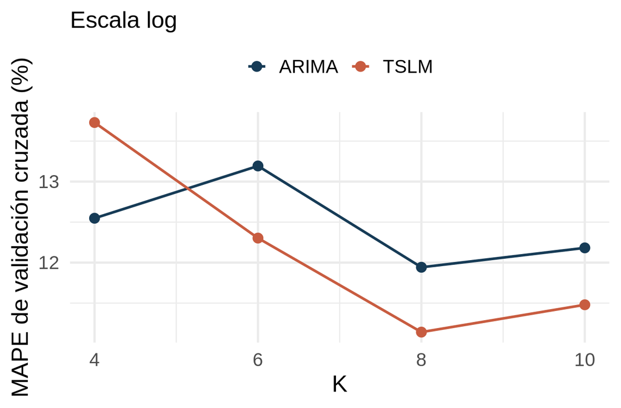

| Escala (K = 8) | ARIMA | TSLM | (ARIMA+TSLM)/2 |
| --- | --- | --- | --- |
| Log | 11.94 | 11.14 | 11.30 |
| Box-Cox (λ = 0.33) | 12.16 | 11.12 | 11.47 |
| Original | 12.10 | 11.65 | 11.82 |

| Escala | K | Errores ARIMA |
| --- | --- | --- |
| log | 4 | (2,1,1) |
| log | 6 | (1,1,2) |
| log | 8 | (1,1,2) |
| log | 10 | (1,1,2) |
| boxcox | 8 | (2,1,1) |
| original | 8 | (1,1,1) + const. |

## ¿Cada regresor aporta? Validación cruzada quitando uno a la vez

```r
o8 <- candidatos_k$orden[[which(candidatos_k$escala == "log" & candidatos_k$K == 8)]]

combinacion <- function(regresores) {        # (ARIMA + TSLM) / 2 en log, K = 8, orden fijo
  lado_derecho <- paste(c("fourier(period = 'year', K = 8)", regresores), collapse = " + ")
  f_arima <- as.formula(sprintf("log(total) ~ %d + %s + pdq(%d, %d, %d) + PDQ(0, 0, 0)",
                                as.integer(o8$constante), lado_derecho, o8$p, o8$d, o8$q))
  f_tslm <- as.formula(paste("log(total) ~ trend() +", lado_derecho))
  (ARIMA(!!f_arima) + TSLM(!!f_tslm)) / 2
}
```

```r
domingo_pascua <- as.Date(Easter(2021:2026))                   # timeDate::Easter()

# Candidatos de calendario que se prueban en la ablación (no entran al modelo final)
candidatos_cal <- tibble(fecha = seq(as.Date("2020-12-28"), as.Date("2026-10-18"), by = "day")) |>
  mutate(semana = yearweek(fecha), md = format(fecha, "%m-%d"),
         dia_semana = wday(fecha, week_start = 1)) |>
  group_by(semana) |>
  summarise(
    nav_0 = as.integer(any(md == "12-24")), nav_1 = as.integer(any(md == "12-17")),
    nav_2 = as.integer(any(md == "12-10")), fin_anio = as.integer(any(md == "12-31")),
    sep16 = as.integer(any(md == "09-16")),                        # semana del 16 de septiembre
    pascua = as.integer(any(fecha %in% (domingo_pascua + 1))),     # semana siguiente a Semana Santa
    quincena = sum(dia_semana <= 6 & (mday(fecha) == 15 | mday(fecha + 1) == 1)),  # días de pago
    ene_w01 = as.integer(any(md == "01-04"))                     # primera semana ISO del año
  )

entrenamiento_ext <- entrenamiento_cv |> left_join(candidatos_cal, by = "semana")
prueba_ext <- prueba_cv |> left_join(candidatos_cal, by = "semana")

completos <- c("festivos", "semana_santa", "evento_2021w43")
fit_cv_ablacion <- entrenamiento_ext |>
  model(
    completo        = combinacion(completos),
    sin_festivos    = combinacion(c("semana_santa", "evento_2021w43")),
    sin_semanasanta = combinacion(c("festivos", "evento_2021w43")),
    sin_evento      = combinacion(c("festivos", "semana_santa")),
    solo_fourier    = combinacion(character()),
    mas_diciembre   = combinacion(c(completos, "nav_0", "nav_1", "nav_2", "fin_anio")),
    mas_sep16       = combinacion(c(completos, "sep16")),       # efecto propio del 16 de sep
    mas_pascua      = combinacion(c(completos, "pascua")),
    mas_quincena    = combinacion(c(completos, "quincena")),
    mas_enero       = combinacion(c(completos, "ene_w01"))       # caída de la 1.ª semana de enero
  )
err_ablacion <- fit_cv_ablacion |> forecast(new_data = prueba_ext) |> errores_cv()
res_ablacion <- resumen_cv(err_ablacion)
mape_completo <- res_ablacion$MAPE_CV[res_ablacion$.model == "completo"]
cambio <- setNames(res_ablacion$MAPE_CV - mape_completo, res_ablacion$.model)

gana_final <- err_ablacion |>                    # folds (de 31) en que la variante le gana al final
  group_by(.model, .id) |>
  summarise(mape = mean(ape), .groups = "drop") |>
  pivot_wider(names_from = .model, values_from = mape) |>
  summarise(across(-c(.id, completo), \(x) sum(x < completo))) |>
  unlist()

semana16 <- err_ablacion |>                      # error en la semana del 16 de sep (6 pronósticos)
  semi_join(filter(candidatos_cal, sep16 == 1), by = "semana") |>
  group_by(.model) |>
  summarise(ape16 = mean(ape), sesgo16 = mean(pe))
ape16 <- setNames(semana16$ape16, semana16$.model)
```

## ¿Cada regresor aporta? Resultados

| Variante de la combinación | MAPE CV (%) | Cambio vs final (pp) | Peor fold (%) | Folds que gana (de 31) |
| --- | --- | --- | --- | --- |
| Agregar semana de Pascua | 11.29 | -0.02 | 16.60 | 16 |
| Modelo final: Fourier + festivos + Semana Santa + evento | 11.30 | 0.00 | 16.51 | — |
| Agregar días de quincena | 11.32 | 0.02 | 16.52 | 15 |
| Agregar indicadora propia del 16 de septiembre | 11.54 | 0.23 | 16.91 | 14 |
| Quitar festivos | 11.69 | 0.39 | 17.65 | 11 |
| Agregar primera semana de enero | 11.80 | 0.49 | 18.05 | 12 |
| Quitar evento 2021-W43 | 11.85 | 0.54 | 18.11 | 14 |
| Agregar 4 indicadoras de diciembre | 11.94 | 0.64 | 17.21 | 13 |
| Quitar Semana Santa | 12.15 | 0.85 | 19.32 | 11 |
| Solo Fourier (sin calendario) | 12.91 | 1.61 | 19.84 | 6 |

Quitar cualquier regresor del calendario sube el error. Ninguno de los cinco regresores extra mejora de forma consistente: el mejor, «semana de Pascua», cambia el MAPE -0.02 pp y gana en 16 de 31 folds, un empate; así que no los usamos.

## Por qué combinar: la TSLM se pasa de forma sistemática

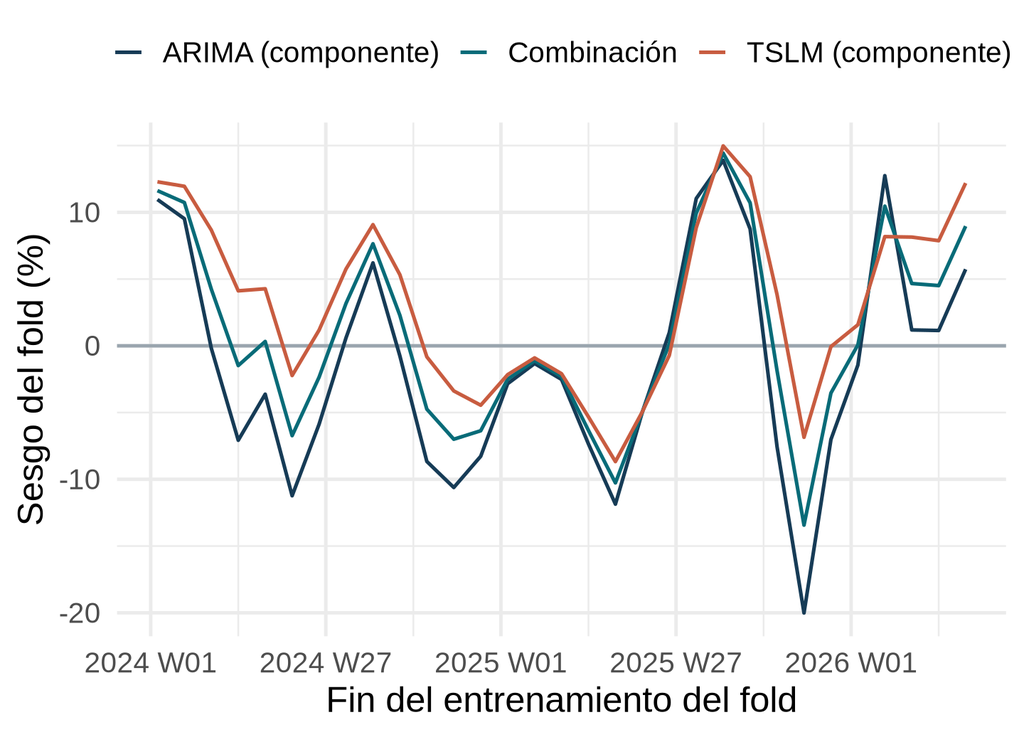

| Modelo | MAPE CV | Sesgo | Sesgo últ. 8 | Peor fold |
| --- | --- | --- | --- | --- |
| TSLM | 11.14 | 3.17 | 4.36 | 17.43 |
| Combinación | 11.30 | 0.93 | 1.23 | 16.51 |
| ARIMA | 11.94 | -1.30 | -1.90 | 20.01 |

- La TSLM queda arriba del ARIMA en **28 de 31** folds.
- Frente a la TSLM sola, la combinación gana en **19 de 31** folds y baja el peor fold.

## Modelo final y verificación con `report()`

```r
# Funciones que crean cada especificación (cada model() recibe un objeto nuevo)
spec_arima <- function() ARIMA(log(total) ~ fourier(period = "year", K = 8) +
                                 festivos + semana_santa + evento_2021w43 + PDQ(0, 0, 0))
spec_tslm <- function() TSLM(log(total) ~ trend() + fourier(period = "year", K = 8) +
                               festivos + semana_santa + evento_2021w43)

fit_final <- datos |>                                   # 290 semanas, todos los datos
  model(arima = spec_arima(), tslm = spec_tslm()) |>
  mutate(combinacion = (arima + tslm) / 2)
```

- Errores del ARIMA con todos los datos: **ARIMA(1,1,2)**, sin constante; con datos solo hasta el primer origen de la CV, la búsqueda elegía ARIMA(2,1,1).
- Efecto estimado (ARIMA / TSLM): festivo **-12% / -12%**; Semana Santa **-27% / -27%**.

## `report()`: componente ARIMA

```
Series: total
Model: LM w/ ARIMA(1,1,2) errors
Transformation: log(total)

Coefficients:
         ar1      ma1     ma2  fourier(period = "year", K = 8)C1_52
      0.4472  -1.4009  0.4718                                0.0763
s.e.  0.3495   0.3310  0.2874                                0.0193
      fourier(period = "year", K = 8)S1_52
                                   -0.0491
s.e.                                0.0198
      fourier(period = "year", K = 8)C2_52
                                    0.1027
s.e.                                0.0140
      fourier(period = "year", K = 8)S2_52
                                   -0.0877
s.e.                                0.0138
      fourier(period = "year", K = 8)C3_52
                                    0.0237
s.e.                                0.0129
      fourier(period = "year", K = 8)S3_52
                                   -0.0296
s.e.                                0.0130
      fourier(period = "year", K = 8)C4_52
                                    0.0305
s.e.                                0.0129
      fourier(period = "year", K = 8)S4_52
                                   -0.0684
s.e.                                0.0127
      fourier(period = "year", K = 8)C5_52
                                    0.0287
s.e.                                0.0129
      fourier(period = "year", K = 8)S5_52
                                    -0.069
s.e.                                 0.013
      fourier(period = "year", K = 8)C6_52
                                    0.0163
s.e.                                0.0132
      fourier(period = "year", K = 8)S6_52
                                   -0.0994
s.e.                                0.0131
      fourier(period = "year", K = 8)C7_52
                                   -0.0264
s.e.                                0.0133
      fourier(period = "year", K = 8)S7_52
                                   -0.0446
s.e.                                0.0134
      fourier(period = "year", K = 8)C8_52
                                   -0.0111
s.e.                                0.0136
      fourier(period = "year", K = 8)S8_52  festivos  semana_santa
                                   -0.0757   -0.1265       -0.3170
s.e.                                0.0141    0.0335        0.0789
      evento_2021w43
              1.0024
s.e.          0.1759

sigma^2 estimated as 0.03284:  log likelihood=94.23
AIC=-142.46   AICc=-138.29   BIC=-58.13
```

## `report()`: componente TSLM y la combinación

```
Series: total
Model: TSLM
Transformation: log(total)

Residuals:
      Min        1Q    Median        3Q       Max
-0.607926 -0.100616  0.008193  0.102307  0.499923

Coefficients:
                                       Estimate Std. Error t value Pr(>|t|)
(Intercept)                          10.4276009  0.0208658 499.746  < 2e-16 ***
trend()                               0.0036876  0.0001218  30.266  < 2e-16 ***
fourier(period = "year", K = 8)C1_52  0.0814205  0.0147305   5.527 7.68e-08 ***
fourier(period = "year", K = 8)S1_52 -0.0575708  0.0148335  -3.881 0.000131 ***
fourier(period = "year", K = 8)C2_52  0.1005743  0.0146824   6.850 5.01e-11 ***
fourier(period = "year", K = 8)S2_52 -0.0882990  0.0144911  -6.093 3.81e-09 ***
fourier(period = "year", K = 8)C3_52  0.0253429  0.0145893   1.737 0.083517 .
fourier(period = "year", K = 8)S3_52 -0.0309250  0.0146676  -2.108 0.035922 *
fourier(period = "year", K = 8)C4_52  0.0289626  0.0146706   1.974 0.049383 *
fourier(period = "year", K = 8)S4_52 -0.0699183  0.0144817  -4.828 2.32e-06 ***
fourier(period = "year", K = 8)C5_52  0.0290102  0.0145332   1.996 0.046928 *
fourier(period = "year", K = 8)S5_52 -0.0692571  0.0145939  -4.746 3.38e-06 ***
fourier(period = "year", K = 8)C6_52  0.0157014  0.0146162   1.074 0.283673
fourier(period = "year", K = 8)S6_52 -0.1004422  0.0145040  -6.925 3.20e-11 ***
fourier(period = "year", K = 8)C7_52 -0.0266557  0.0144602  -1.843 0.066373 .
fourier(period = "year", K = 8)S7_52 -0.0439089  0.0145416  -3.020 0.002775 **
fourier(period = "year", K = 8)C8_52 -0.0109175  0.0145965  -0.748 0.455142
fourier(period = "year", K = 8)S8_52 -0.0764700  0.0150540  -5.080 7.08e-07 ***
festivos                             -0.1266729  0.0342758  -3.696 0.000266 ***
semana_santa                         -0.3118154  0.0807149  -3.863 0.000140 ***
evento_2021w43                        1.0300777  0.1787921   5.761 2.28e-08 ***
---
Signif. codes:  0 '***' 0.001 '**' 0.01 '*' 0.05 '.' 0.1 ' ' 1

Residual standard error: 0.1724 on 269 degrees of freedom
Multiple R-squared: 0.8278, Adjusted R-squared: 0.815
F-statistic: 64.67 on 20 and 269 DF, p-value: < 2.22e-16
```

## Los efectos son estables entre folds

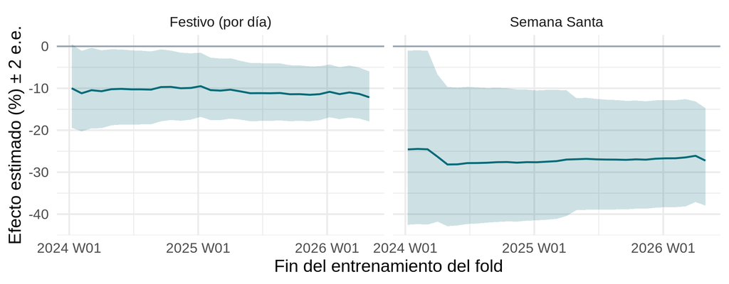

# Evaluación

## Validación cruzada de los modelos sin regresores

```r
fit_cv_sin <- entrenamiento_cv |>
  model(
    benchmark = spec_benchmark,
    holt_amortiguado = decomposition_model(
      STL(total ~ season(period = "year"), robust = TRUE),
      ETS(season_adjust ~ error("A") + trend("Ad") + season("N")),
      SNAIVE(season_year ~ lag(52))),                 # mismo default, declarado
    holt_amortiguado_log = decomposition_model(
      STL(log(total) ~ season(period = "year"), robust = TRUE),
      ETS(season_adjust ~ error("A") + trend("Ad") + season("N")),
      SNAIVE(season_year ~ lag(52))),
    stl_arima_log = decomposition_model(
      STL(log(total) ~ season(period = "year"), robust = TRUE),
      ARIMA(season_adjust ~ PDQ(0, 0, 0)),
      SNAIVE(season_year ~ lag(52)))
  )
```

[output not shown]

```r
err_sin <- fit_cv_sin |> forecast(h = 12) |> errores_cv()
```

## Validación cruzada: final vs benchmark vs mejor sin regresores

| Modelo | MAPE CV (%) | Mediana | Peor fold | Sesgo |
| --- | --- | --- | --- | --- |
| Final (combinación) | 11.30 | 10.76 | 16.51 | 0.93 |
| Referencia: solo Fourier | 12.91 | 12.53 | 19.84 | 0.98 |
| Benchmark | 14.74 | 14.76 | 21.23 | -0.81 |
| Mejor sin regresores | 15.17 | 15.42 | 22.82 | -0.40 |

- Mejor sin regresores (de 3 probados): **STL + Holt amortiguado (escala original)**, 15.17%.
- El final gana al benchmark en **27 de 31** folds y al mejor sin regresores en **28 de 31**.

## Otras especificaciones probadas

```r
# ARIMA con tendencia determinística y errores ARMA estacionarios (d = 0):
# orden elegido automáticamente con todos los datos y fijado en la validación cruzada
spec_d0 <- (datos |>
  model(m = ARIMA(log(total) ~ trend() + fourier(period = "year", K = 8) + festivos +
                    semana_santa + evento_2021w43 + pdq(d = 0) + PDQ(0, 0, 0))))$m[[1]]$fit$spec

f_d0 <- as.formula(sprintf(
  "log(total) ~ %d + trend() + fourier(period = 'year', K = 8) + %s + pdq(%d, 0, %d) + PDQ(0, 0, 0)",
  as.integer(spec_d0$constant), calendario_txt, spec_d0$p, spec_d0$q))

err_d0 <- entrenamiento_cv |>
  model(arima_d0 = ARIMA(!!f_d0)) |>
  forecast(new_data = prueba_cv) |>
  errores_cv()

promedio <- function(err, nombre) {              # combinación = promedio de los .mean
  err |>
    group_by(.id, semana, h, total) |>
    summarise(.mean = mean(.mean), .groups = "drop") |>
    mutate(.model = nombre, ape = 100 * abs(total - .mean) / total,
           pe = 100 * (.mean - total) / total)
}

componentes_alt <- bind_rows(err_k |> filter(.model %in% c("ARIMA_K8_log", "TSLM_K8_log")),
                             err_sin |> filter(.model == "benchmark"), err_d0)

err_alt <- bind_rows(
  err_ablacion |> filter(.model == "completo") |> mutate(.model = "final"),
  err_d0,
  promedio(filter(componentes_alt, .model %in% c("arima_d0", "TSLM_K8_log")), "comb_d0"),
  promedio(filter(componentes_alt, .model %in% c("ARIMA_K8_log", "TSLM_K8_log", "benchmark")),
           "comb_benchmark")
)

res_alt <- resumen_cv(err_alt)
m_alt <- setNames(res_alt$MAPE_CV, res_alt$.model)
s_alt <- setNames(res_alt$sesgo, res_alt$.model)
gana_alt <- err_alt |>                           # folds (de 31) en que le gana al final
  group_by(.model, .id) |>
  summarise(mape = mean(ape), .groups = "drop") |>
  pivot_wider(names_from = .model, values_from = mape) |>
  summarise(across(-c(.id, final), \(x) sum(x < final))) |>
  unlist()

etiquetas_alt <- c(final = "Final: (ARIMA d = 1 + TSLM) / 2",
                   arima_d0 = "ARIMA con tendencia, d = 0",
                   comb_d0 = "(ARIMA d = 0 + TSLM) / 2",
                   comb_benchmark = "(ARIMA + TSLM + benchmark) / 3")

res_alt |>
  mutate(gana = ifelse(.model == "final", "—", as.character(gana_alt[.model])),
         .model = etiquetas_alt[.model]) |>
  select(.model, MAPE_CV, mediana, peor_fold, sesgo, gana) |>
  kable(digits = 2, col.names = c("Modelo", "MAPE CV (%)", "Mediana", "Peor fold", "Sesgo",
                                  "Folds que gana (de 31)"))
```

| Modelo | MAPE CV (%) | Mediana | Peor fold | Sesgo | Folds que gana (de 31) |
| --- | --- | --- | --- | --- | --- |
| (ARIMA d = 0 + TSLM) / 2 | 11.15 | 10.74 | 17.19 | 3.04 | 12 |
| ARIMA con tendencia, d = 0 | 11.18 | 10.70 | 16.95 | 2.91 | 14 |
| Final: (ARIMA d = 1 + TSLM) / 2 | 11.30 | 10.76 | 16.51 | 0.93 | — |
| (ARIMA + TSLM + benchmark) / 3 | 11.90 | 12.03 | 16.92 | 0.35 | 7 |

## Error por horizonte

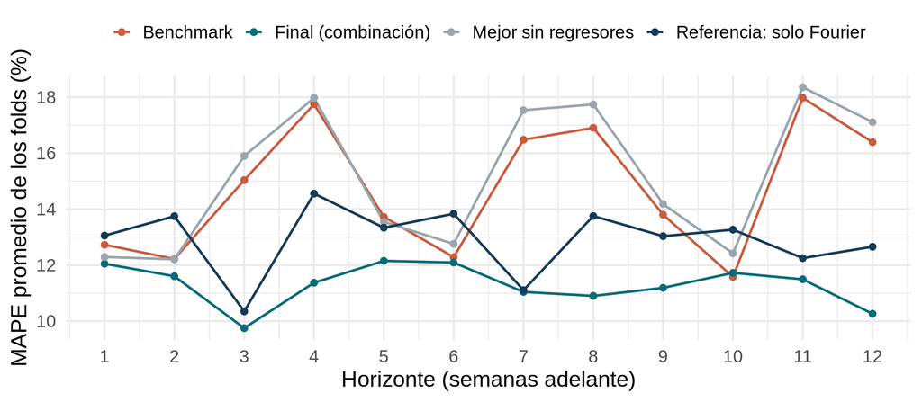

## Ventanas análogas a la del concurso (W31–W42)

| Modelo | 2024 W31–W42 | 2025 W31–W42 | Promedio |
| --- | --- | --- | --- |
| Final (combinación) | 8.83 | 12.37 | 10.60 |
| Referencia: solo Fourier | 9.32 | 12.53 | 10.93 |
| Benchmark | 11.84 | 14.88 | 13.36 |
| Mejor sin regresores | 12.07 | 16.14 | 14.10 |

## Residuales del modelo final (290 semanas)

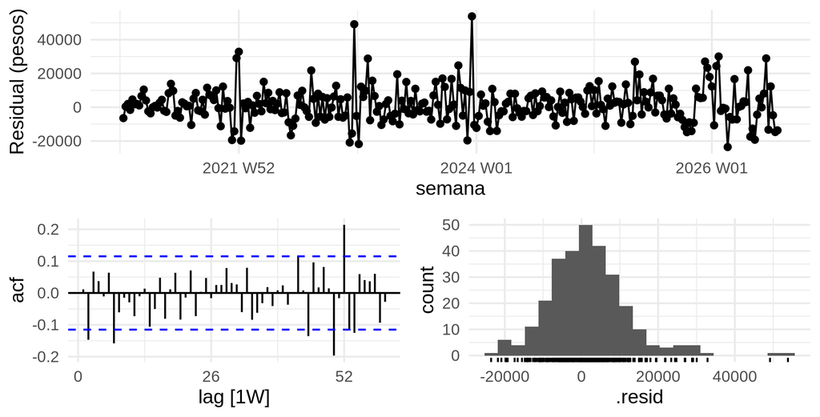

## Pruebas de Ljung-Box

| Modelo | Rezagos | Estadístico Q | p-valor |
| --- | --- | --- | --- |
| ARIMA (innov. en log) | 12 | 16.07 | 0.066 |
| ARIMA (innov. en log) | 52 | 91.12 | 0.00024 |
| TSLM (innov. en log) | 12 | 14.54 | 0.27 |
| TSLM (innov. en log) | 52 | 100.01 | <1e-04 |
| Combinación (residuales en pesos) | 12 | 19.93 | 0.068 |
| Combinación (residuales en pesos) | 52 | 92.48 | 0.00047 |

- Media de residuales de la combinación: **1,676 pesos** (2.7% del nivel; t = 2.71).
- Sesgo **fuera de muestra** del pronóstico (`.mean`) en validación cruzada: **+0.9%**.

## ¿Cuánto mejora el pronóstico con contexto?

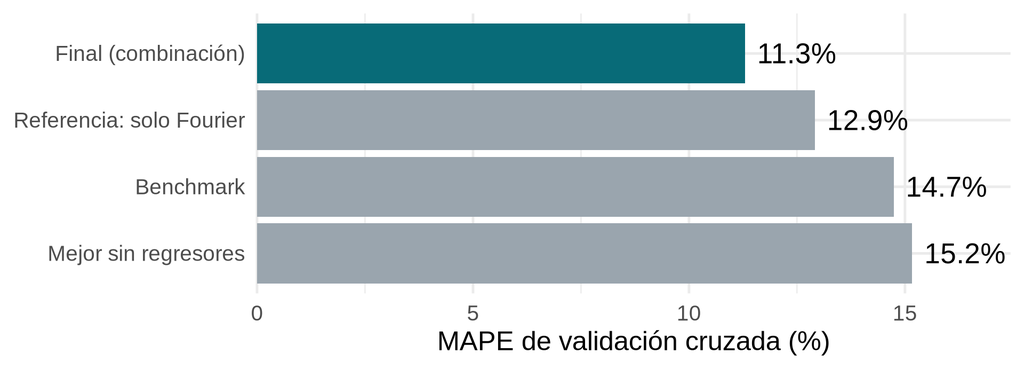

- Contra el benchmark: **3.4 pp menos** (23% menos error).
- Contra el mejor sin regresores: **3.9 pp menos**. Solo el calendario, sobre el mismo modelo con Fourier: **1.6 pp**.
- Gana al benchmark en **27 de 31** folds y en **11 de 12** horizontes.

# Pronóstico final

## Pronóstico 2026-W31 a 2026-W42

```r
equipo_8 <- datos |>
  model(equipo_8 = (spec_arima() + spec_tslm()) / 2) |>   # un solo modelo: la combinación
  forecast(new_data = futuro)                          # 12 semanas con sus regresores
```

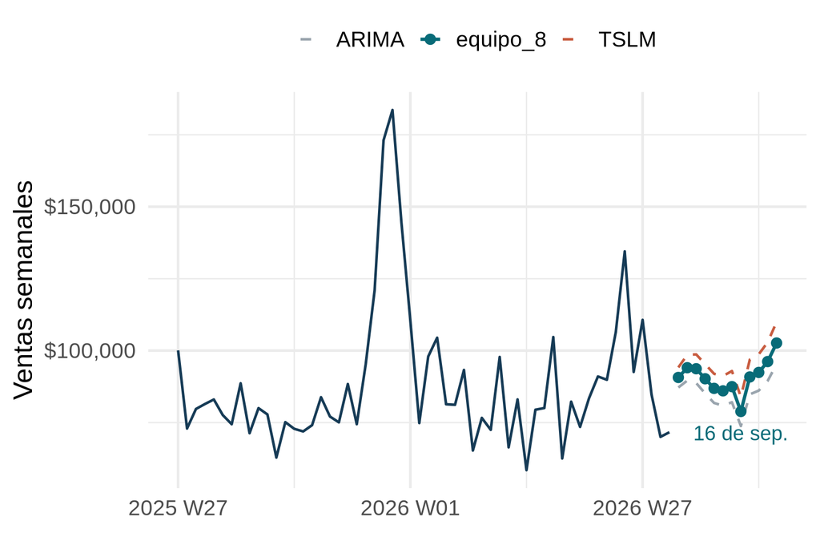

| Semana | .mean (pesos) |
| --- | --- |
| 2026 W31 | 90,685 |
| 2026 W32 | 94,072 |
| 2026 W33 | 93,715 |
| 2026 W34 | 90,233 |
| 2026 W35 | 86,894 |
| 2026 W36 | 86,034 |
| 2026 W37 | 87,498 |
| 2026 W38 | 78,869 |
| 2026 W39 | 90,858 |
| 2026 W40 | 92,424 |
| 2026 W41 | 96,203 |
| 2026 W42 | 102,648 |

## Validación y guardado

```r
validar_entrega <- function(fc, nombre, maestria = FALSE,
                            inicio = yearweek("2026 W31")) {
  semanas_esperadas <- inicio + 0:11
  problemas <- character()

  if (!inherits(fc, "fbl_ts")) {
    stop("El objeto no es un fable (fbl_ts). Debe ser la salida de forecast().")
  }

  idx <- fc[[index_var(fc)]]
  if (!inherits(idx, "yearweek")) {
    problemas <- c(problemas, "El índice no es de clase yearweek.")
  }

  modelos <- unique(fc$.model)
  if (length(modelos) != 1 || modelos[1] != nombre) {
    problemas <- c(problemas, sprintf(
      "Debe haber un solo modelo llamado '%s'. Se encontró: %s",
      nombre, paste(modelos, collapse = ", ")
    ))
  }

  if (nrow(fc) != 12 ||
      !isTRUE(all.equal(sort(as.Date(idx)), as.Date(semanas_esperadas)))) {
    problemas <- c(problemas,
      paste("El pronóstico debe cubrir exactamente 12 semanas, de",
            format(inicio), "a", format(inicio + 11)))
  }

  if (!identical(response_vars(fc), "total")) {
    problemas <- c(problemas, "La variable pronosticada debe llamarse 'total'.")
  }

  if (anyNA(fc$.mean) || any(fc$.mean <= 0)) {
    problemas <- c(problemas, "Hay pronósticos faltantes, negativos o en cero.")
  }

  if (maestria) {
    v <- distributional::variance(fc[[distribution_var(fc)]])
    if (anyNA(v) || any(v <= 0)) {
      problemas <- c(problemas,
        "La distribución del pronóstico es degenerada: no hay intervalos válidos.")
    }
  }

  if (length(problemas) == 0) {
    message("✔ Entrega válida.")
  } else {
    stop(paste0("✖ ", problemas, collapse = "\n"))
  }
  invisible(TRUE)
}

validar_entrega(equipo_8, "equipo_8")
```

```
✔ Entrega válida.
```

```r
save(equipo_8, file = "equipo_8.RData")
```